# Lab 3: Ordinal Regression

PSY 504: Advanced Statistics

Author

Bianca Santi

Published

March 13, 2026

# General Feedback

Good submission, Bianca! Code, models , and write-up are all good and correct.  
I’ve left a few specific comments inline (see Outline for subsections named “Feedback”)  
But here are some comments that transfers across from just ordinal regression/ this assignment:

- In Q4.3b, you say the Odds ratio multiplies the “probability” when it should be multiplies the cumulative *odds.* Remember that OR is not in probability space..

[Download the Lab QMD](https://github.com/suyoghc/PSY504_Spring_2026/raw/main/posts/Ordinal%20Regression/Lab3%20-%20ordinal%20regression%20-%20Q.qmd)

[Link to Solutions Key](https://darling-flan-b8747d.netlify.app/)

# Instructions

- If you are fitting a model, display the model output in a neatly formatted table. (The `tidy()` and `kable()` functions can help!)
- If you are creating a plot, use clear labels for all axes, titles, etc.
- Commit and push your work to GitHub regularly, at least after each exercise. Write short and informative commit messages.
- When you’re done, we should be able to knit the final version of the QMD in your GitHub as an HTML.

# Setup

```r
library(tidyverse)
library(ordinal)
library(marginaleffects)
library(emmeans)
library(car)
library(ggeffects)
library(knitr)
library(modelsummary)
library(patchwork)
library(gofcat)
library(sure)
library(MASS)
library(broom)

options(scipen = 999)
```

# Part 1: Understanding Thresholds Through Simulation

## The Setup

A university has 10 instructors who are **cross-listed** — they each teach one course in the Psychology department and one in Computer Science. At the end of the semester, students in both departments rate these instructors on a 4-point scale: **Poor / Fair / Good / Excellent**.

Each instructor has a latent (hidden) “teaching effectiveness” score that we never observe. We only see the ordinal rating. Now, **both departments evaluate the same instructors**, but their evaluation forms use **different descriptions** for the rating categories.

**Psychology’s form:**

- Poor = “Did not meet basic expectations”
- Fair = “Meets minimum expectations”
- Good = “Consistently above average”
- Excellent = “Outstanding in all respects”

**Computer Science’s form:**

- Poor = “Did not meet basic expectations”
- Fair = “Meets minimum expectations”
- Good = “Solid and competent”
- Excellent = “Solid and competent, with minor distinction”

Notice that in CS, students have to split hairs between “Good” and “Excellent” as the descriptions barely differ. This compresses the top two categories together. Consequently almost everyone who would be “Good” in Psychology ends up rated “Excellent” in CS, not because the teaching improved, but because the **scale changed**.

Here’s the simulation code. **Read it carefully before running it.**

```r
set.seed(504)

# 10 cross-listed instructors with latent teaching effectiveness
instructors <- tibble(
  id = 1:10,
  effectiveness = rnorm(10, mean = 0, sd = 1.2)
)

# Each instructor rated by 20 students per department
ratings_latent <- instructors %>%
  rowwise() %>%
  mutate(latent = list(rnorm(20, mean = effectiveness, sd = 1))) %>%
  unnest(latent) %>%
  ungroup()

# --- THREE THRESHOLDS PRODUCE FOUR CATEGORIES ---

# Psychology: balanced scale
tau_psych <- c(-1.0, 0.0, 1.0)

# Computer Science: compressed top end
tau_cs <- c(-1.0, 0.0, 0.3)

ratings <- ratings_latent %>%
  mutate(
    eval_psych = case_when(
      latent <= tau_psych[1] ~ "Poor",
      latent <= tau_psych[2] ~ "Fair",
      latent <= tau_psych[3] ~ "Good",
      TRUE                   ~ "Excellent"
    ),
    eval_psych = ordered(eval_psych, levels = c("Poor", "Fair", "Good", "Excellent")),

    eval_cs = case_when(
      latent <= tau_cs[1] ~ "Poor",
      latent <= tau_cs[2] ~ "Fair",
      latent <= tau_cs[3] ~ "Good",
      TRUE                ~ "Excellent"
    ),
    eval_cs = ordered(eval_cs, levels = c("Poor", "Fair", "Good", "Excellent"))
  )
```

### Question 1.1: Visualize the latent distribution

Create a density plot of the latent scores with vertical dashed lines for Psychology’s thresholds ($\tau_1 = -1$, $\tau_2 = 0$, $\tau_3 = 1$). Label the four regions (Poor, Fair, Good, Excellent) on the plot.

**TipHint: Key geoms**

`geom_density()` for the curve, `geom_vline(xintercept = ...)` for the thresholds (use `linetype = "dashed"`), and `annotate("text", x = ..., y = ..., label = ...)` to place category labels in each region. You’ll need one `annotate()` call per label.

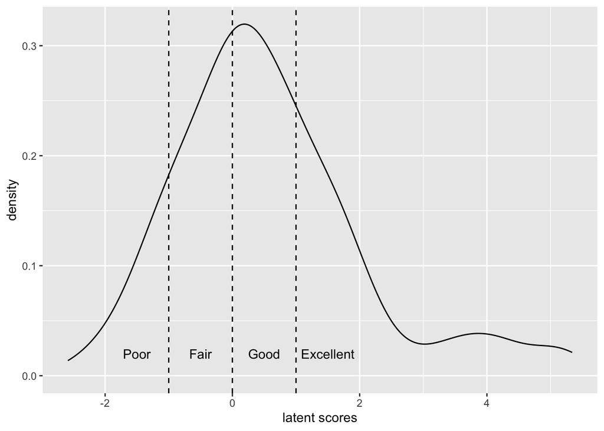

```r
ggplot() +
  # plot density curve for latent scores
  geom_density(data = ratings_latent,
               aes(x = latent)) +
  # vertical dashed lines for psych thresholds
  geom_vline(xintercept = tau_psych[1], linetype = "dashed") +
  geom_vline(xintercept = tau_psych[2], linetype = "dashed") +
  geom_vline(xintercept = tau_psych[3], linetype = "dashed") +
  # add labels to each region
  annotate("text", x = (tau_psych[1] - 0.5), y = 0.02, label = "Poor") +
  annotate("text", x = (tau_psych[2] + tau_psych[1])/2, y = 0.02, label = "Fair") +
  annotate("text", x = (tau_psych[2] + tau_psych[3])/2, y = 0.02, label = "Good") +
  annotate("text", x = (tau_psych[3] + 0.5), y = 0.02, label = "Excellent") +
  # add x axis label
  xlab("latent scores")
```

### Question 1.2: Identical instructors, different scales

Create side-by-side stacked bar charts showing the observed rating distributions for Psychology and CS.

The instructors didn’t change, so what did? What does this tell you about what thresholds control?

**TipHint: Data wrangling**

First, create a frequency table for each department using `count()`, rename the rating column to a shared name like `category`, and add a `dept` label column. Then `bind_rows()` them together. Compute proportions with `mutate(prop = n / sum(n))` grouped by department. Plot with `geom_col(position = "stack")` mapping `x = dept`, `y = prop`, and `fill = category`.

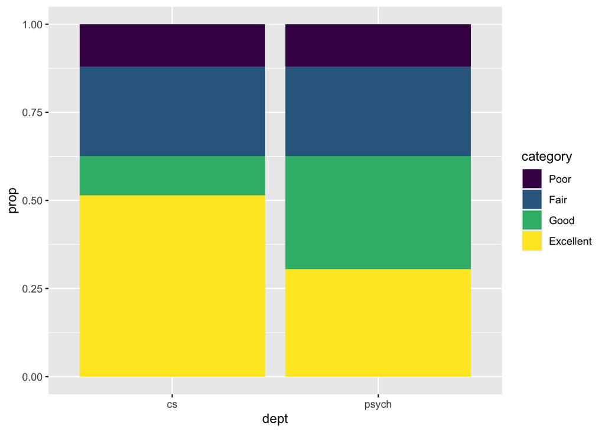

```r
rating_freq_psych <- ratings %>%
  group_by(eval_psych) %>%
  count() %>%
  mutate(dept = "psych") %>%
  rename(category = eval_psych)

rating_freq_cs <- ratings %>%
  group_by(eval_cs) %>%
  count() %>%
  mutate(dept = "cs") %>%
  rename(category = eval_cs)

rating_freq <- bind_rows(rating_freq_psych, rating_freq_cs) %>%
  group_by(dept) %>%
  mutate(prop = n/sum(n))


ggplot(data = rating_freq) +
  geom_col(aes(x = dept, y = prop, fill = category),
           position = "stack")
```

Answer: The only difference between the two departments is the thresholds for the ratings. This means that the thresholds control what category each latent rating will be sorted into.

### Exercise 1.3: What does tau live on?

The thresholds $\tau_1 = -1$, $\tau_2 = 0$, $\tau_3 = 1$ are on the latent “teaching effectiveness” scale — the continuous axis you generated but would never observe in real data. The model re-expresses these same cut points as **log-cumulative-odds** — a transformation of the latent scale that makes the math linear. Convert between them:

1. Convert the Psychology Dept thresholds to cumulative probabilities using `plogis()`. What does each value mean?

**TipHint: What does plogis() do?**

`plogis()` is the inverse logit. It converts log-cumulative-odds back to a probability: $\text{plogis}(\tau) = \frac{e^\tau}{1 + e^\tau} = P(Y \leq k)$

2. Suppose you want a rating distribution where 10% are Poor, 30% Fair, 40% Good, and 20% Excellent. What thresholds would produce this? Use `qlogis()`.

**TipHint: What does qlogis() do?**

`qlogis()` is the logit function, which goes the other direction. Give it a cumulative probability and it returns the threshold: $\text{qlogis}(p) = \log\frac{p}{1-p} = \tau$

**Your turn**

```r
# (a) Thresholds to cumulative probabilities
thresholds <- c(-1.0, 0.0, 1.0)
cumul_probs <- plogis(thresholds)
cumul_probs

# Then get category-specific probabilities
cat_probs <- diff(c(0, cumul_probs, 1))

# (b) Desired split to thresholds
desired_split <- c(0.10, 0.30, 0.40, 0.20)
cumul_desired <- cumsum(desired_split[1:3])  # which elements?
needed_thresholds <- qlogis(cumul_desired)
needed_thresholds
```

[output not shown]

Answers:

1. Each cumulative probability value represents the probability of getting anything under that threshold.
2. The thresholds that would produce this are (-2.1972246, -0.4054651, 1.3862944)

**Expected output**

1. Cumulative probs: 0.269, 0.500, 0.731 Category probs: 0.269, 0.231, 0.231, 0.269
2. Cumulative at cuts: 0.10, 0.40, 0.80 Required thresholds: -2.197, -0.405, 1.386

# Part 2: Manual Calculation — From Counts to Log-Cumulative-Odds

The goal of this section is to **demystify model output**. When you later see `Poor|Fair = -1.23` in a `clm()` summary, you’ll think: “that’s the log-cumulative-odds I already computed by hand.”

### Exercise 2.1: Build the table

Using Psychology Dept’s ratings, compute the following for each category: the count, proportion, cumulative proportion, cumulative odds, and log-cumulative-odds.

Display the result as a table using `kable()`.

**Your turn**

```r
hand_calc <- ratings %>%
  count(eval_psych) %>%
  rename(category = eval_psych) %>%
  mutate(
    proportion     = n / sum(n),
    cumul_proportion = cumsum(proportion),
    cumul_odds       = cumul_proportion / (1 - cumul_proportion),
    log_cumul_odds   = log(cumul_odds)
  )

hand_calc %>% kable(digits = 3)
```

[output not shown]

**Hint: What’s cumulative odds?**

Cumulative odds = $\frac{P(Y \leq k)}{P(Y > k)} = \frac{\text{cum\_proportion}}{1 - \text{cum\_proportion}}$

Then take `log()` (natural log, not log10).

The last category (Excellent) will be `Inf`. This is because $P(Y \leq \text{Excellent}) = 1$, so the odds are $1/0 = \infty$.

### Question 2.2: Compare to model output

Fit an intercept-only ordinal model on the Psychology Dept data: `clm(eval_psych ~ 1, data = ratings)`.

Compare the model’s threshold estimates to your hand-calculated log-cumulative-odds. How do they compare, and what does this tell you about what the model is doing?

```r
kable(tidy(clm(eval_psych ~ 1, data = ratings)))
```

| term | estimate | std.error | statistic | p.value | coef.type |
| --- | --- | --- | --- | --- | --- |
| Poor\|Fair | -1.9924302 | 0.2175971 | -9.156512 | 0.0000000 | intercept |
| Fair\|Good | -0.5108256 | 0.1460593 | -3.497384 | 0.0004698 | intercept |
| Good\|Excellent | 0.8236001 | 0.1535828 | 5.362579 | 0.0000001 | intercept |

Answer: The model thresholds are very similar to the hand-calculated log-cumulative-odds, which confirms that the model is trying to estimate category boundaries in the log cumulative odds space.

#### Feedback

**ImportantFeedback**

Correct! Good understanding.

### Question 2.3: Cumulative probability plot

Run the code below. It visualizes the numbers you computed in Exercise 2.1, with gray bars showing cumulative probabilities and blue segments showing category-specific probabilities.

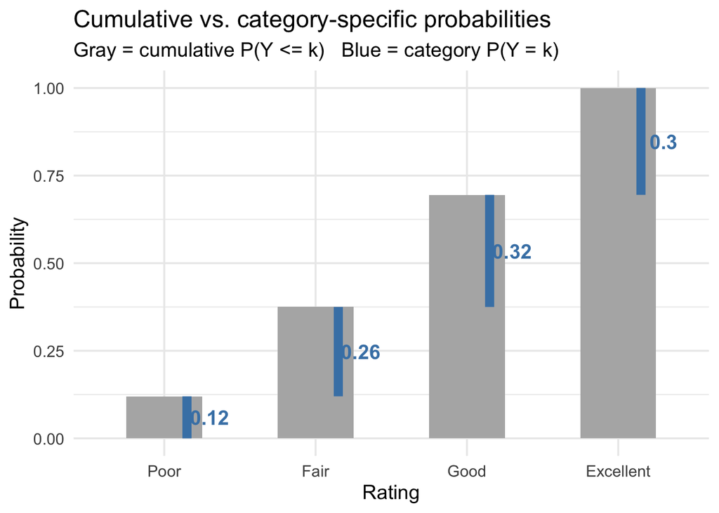

```r
freq_table <- ratings %>%
  count(eval_psych) %>%
  rename(category = eval_psych) %>%
  mutate(
    prop = n / sum(n),
    cumul_prop = cumsum(prop),
    cumul_prop_lag = lag(cumul_prop, default = 0)
  )

ggplot(freq_table) +
  geom_col(aes(x = category, y = cumul_prop),
           fill = "gray70", width = 0.5) +
  geom_segment(aes(x = as.numeric(category) + 0.15,
                   xend = as.numeric(category) + 0.15,
                   y = cumul_prop_lag, yend = cumul_prop),
               color = "steelblue", linewidth = 3) +
  geom_text(aes(x = as.numeric(category) + 0.3,
                y = (cumul_prop + cumul_prop_lag) / 2,
                label = round(prop, 2)),
            color = "steelblue", size = 5, fontface = "bold") +
  scale_y_continuous(limits = c(0, 1), breaks = seq(0, 1, 0.25)) +
  labs(
    title = "Cumulative vs. category-specific probabilities",
    subtitle = "Gray = cumulative P(Y <= k)   Blue = category P(Y = k)",
    x = "Rating", y = "Probability"
  ) +
  theme_minimal(base_size = 14)
```

Answer these questions:

What do the gray bar and blue segment for “Fair” represent? Write them as probability statements.

Answer:

The gray bar represents the cumulative probability of outcomes that are below the threshold between Fair and Good, P(rating < tau_2) or P(Fair) + P(Poor).

The blue segment represents the probability of an outcome being Fair, P(tau_1 < rating < tau_2) or P(Fair).

#### Feedback

**ImportantFeedback**

Good!

# Part 3: Conceptual Questions

### Question 3.1

How does the **cumulative logit** link function differ from the ordinary logit link used in binary logistic regression?

The cumulative logit is: $\log\frac{P(Y \leq k)}{P(Y > k)}$

For an outcome with $K$ categories, how many equations does this produce? Answer in 2–3 sentences.

Answer: The cumulative logit function computes log odds for each cumulative probability (for each category) as opposed to computing log odds for probability (normal logit link). For an outcome with $K$ categories, this produces $K - 1$ equations, one for each boundary between categories.

### Question 3.2: Why not just use linear regression (aka metric models)?

Linear regression, ANOVA, and t-tests are all metric models. Metric models assume the numbers you assign to categories have equal spacing and meaningful distances, where you’re treating your scale like a ruler with evenly spaced tick marks.

Using the simulation data, code Psychology Dept ratings as numbers: Poor = 1, Fair = 2, Good = 3, Excellent = 4. Fit `lm(rating_numeric ~ effectiveness)`. Then recode as Poor = 1, Fair = 2, Good = 3, Excellent = 10. Fit the model again.

Report both slopes. In one sentence, explain why they differ and what this reveals about metric models.

```r
ratings_numeric_1 <- ratings %>%
  mutate(rating_numeric = case_when(
    eval_psych == "Poor" ~ 1,
    eval_psych == "Fair" ~ 2,
    eval_psych == "Good" ~ 3,
    eval_psych == "Excellent" ~ 4
  ))

ratings_numeric_2 <- ratings %>%
  mutate(rating_numeric = case_when(
    eval_psych == "Poor" ~ 1,
    eval_psych == "Fair" ~ 2,
    eval_psych == "Good" ~ 3,
    eval_psych == "Excellent" ~ 10
  ))


linear_model_1 <- lm(rating_numeric ~ effectiveness, data = ratings_numeric_1)
linear_model_2 <- lm(rating_numeric ~ effectiveness, data = ratings_numeric_2)

linear_model_1$coefficients["effectiveness"]
```

```
effectiveness
    0.4517783
```

```r
linear_model_2$coefficients["effectiveness"]
```

```
effectiveness
     1.705881
```

Answer: The slopes differ because the linear model is treating the numeric ratings as numeric, so different values for the excellent category lead to different fits of the ratings to the underlying real effectiveness.

#### Feedback

**ImportantFeedback**

Yes, OLS *assumes equal spacing* between categories. The ordinal model makes no such assumption, so it would give the same result regardless of numeric coding.

# Part 4: Modeling the GBBO Data

The data comes from the Great British Bake Off (GBBO). In each episode, bakers face a “technical challenge” where they receive a recipe with minimal instructions and are judged blind. The judges rank every baker from best to worst.

We will focus on the **top 3 finishers**. Rank is ordinal, as 1st is better than 2nd and 2nd is better than 3rd, but we cannot say the gap between 1st and 2nd equals the gap between 2nd and 3rd. This is the kind of data that ordinal regression is suited for.

Do Gender and Age predict how bakers rank in the technical?

```r
gbbo <- read_csv("https://raw.githubusercontent.com/suyoghc/PSY-504_Spring-2025/refs/heads/main/Ordinal%20Regression/data/GBBO.csv")
```

### Exercise 4.1: Prepare the data

Filter to only top 3 ranks. Convert `Rank` to an ordered factor (1 = best, so think about the ordering). Convert `Gender` to a factor.

**TipHint: Factor ordering**

The column is called `Technical Rank` (with a space), so rename it first with `rename(Rank = \`Technical Rank`)`.

What does “higher” mean here? Rank 1 is best. You need to decide whether your ordered factor goes 1 < 2 < 3 (best to worst) or 3 < 2 < 1 (worst to best). The model interprets higher factor levels as “more” of the outcome. Think about what direction makes sense for your interpretation.

```r
gb <- gbbo %>%
  rename(Rank = `Technical Rank`) %>%   # fix column name
  filter(Rank %in% c(1, 2, 3)) %>%
  drop_na() %>%
  mutate(
    Rank = ordered(Rank, levels = c(3, 2, 1)),  # 3 < 2 < 1, so "higher" = better rank
    Gender = factor(Gender)
  )

head(gb)
```

```
# A tibble: 6 × 3
  Gender   Age Rank
  <fct>  <dbl> <ord>
1 F         30 2
2 M         31 3
3 M         24 1
4 F         45 2
5 M         25 1
6 F         37 3
```

```r
table(gb$Rank)
```

```
  3   2   1
102 104 103
```

### Question 4.2: Explore

Create two visualizations:

1. A bar chart showing the proportion of bakers in each rank by Gender.
2. A bar chart showing the proportion of bakers in each rank by Age (bin Age into groups using `cut()`).

**TipHint: Proportional bar charts**

`geom_bar(position = "fill")` gives proportions instead of counts. Map `x = Gender` (or your age groups) and `fill = Rank`. For part (b), create age bins with something like `cut(Age, breaks = c(15, 25, 35, 45, 55, 75))` inside a `mutate()` before plotting.

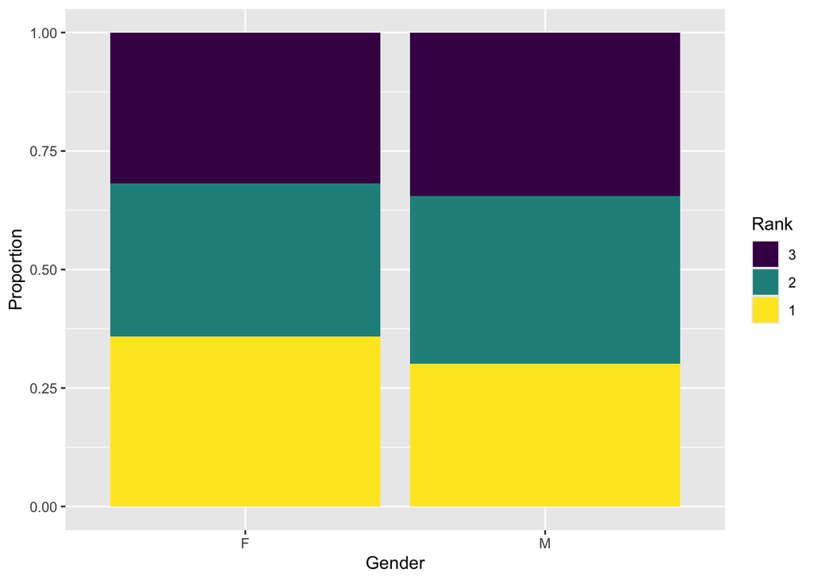

```r
# rank by gender plot
ggplot(data = gb) +
  geom_bar(aes(x = Gender, fill = Rank), position = "fill") +
  ylab("Proportion")
```

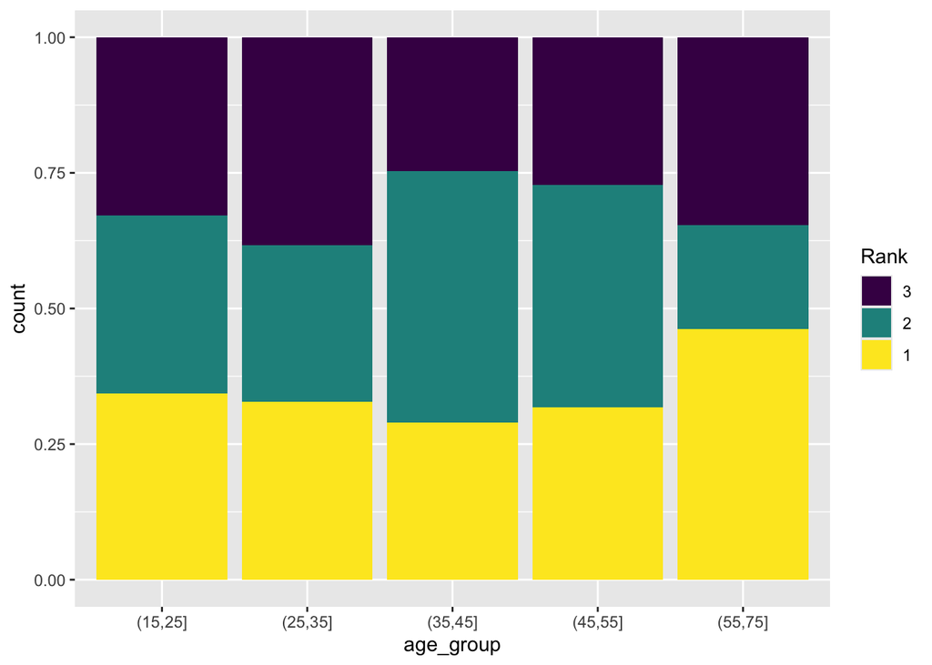

```r
# rank by age plot
ggplot(data = gb %>%
         mutate(age_group = cut(Age, breaks = c(15, 25, 35, 45, 55, 75)))) +
  geom_bar(aes(x = age_group, fill = Rank), position = "fill")
```

### Question 4.3: Build models

Fit the following models using `clm()` from the `ordinal` package:

- **Model 0:** Intercept only — `Rank ~ 1`
- **Model 1:** `Rank ~ Gender`
- **Model 2:** `Rank ~ Gender + Age`
- **Model 3:** `Rank ~ Gender * Age`

For Model 2:

1. Report the threshold estimates. What do they represent?
2. Exponentiate the coefficients. Interpret the odds ratio for `Age` in one sentence.
3. Using Model 2, what is the predicted probability of Rank 1 for a 30-year-old female? Use `predictions()` from the `marginaleffects` package.

**TipHint: Interpreting thresholds**

The thresholds are the log-cumulative-odds of $P(Y \leq k)$ when all predictors are zero. They define the baseline distribution — where the cuts fall before any predictor shifts the distribution.

```r
m0 <- clm(Rank ~ 1, data = gb)
m1 <- clm(Rank ~ Gender, data = gb)
m2 <- clm(Rank ~ Gender + Age, data = gb)
m3 <- clm(Rank ~ Gender * Age, data = gb)
```

```r
m2$coefficients
```

```
         3|2          2|1      GenderM          Age
-0.600496501  0.804822497 -0.190952025  0.005618057
```

Answer: the threshold estimates represent the estimates for the threshold between the three ranks in log cumulative odds space, before any additional effects from gender or age (when all predictors = 0/default values).

```r
kable(tidy(m2, exponentiate = TRUE))
```

| term | estimate | std.error | statistic | p.value | coef.type |
| --- | --- | --- | --- | --- | --- |
| 3\|2 | 0.5485392 | 0.3493038 | -1.7191240 | 0.0855918 | intercept |
| 2\|1 | 2.2362995 | 0.3507357 | 2.2946693 | 0.0217521 | intercept |
| GenderM | 0.8261722 | 0.2106070 | -0.9066745 | 0.3645790 | location |
| Age | 1.0056339 | 0.0090998 | 0.6173821 | 0.5369827 | location |

Answer: For Age, each additional year multiplies the probability of being in a higher rank by 1.0056

#### Feedback

**ImportantFeedback**

The OR does not multiply the probability. It multiplies the cumulative *odds*!  
Correct phrasing: “For each additional year of age, *the cumulative odds* of being in a higher rank category *are multiplied* by 1.006.”

```r
kable(predictions(m2, newdata = datagrid(Gender = "F", Age = 30)))
```

| rowid | group | estimate | std.error | statistic | p.value | s.value | conf.low | conf.high | Rank | Gender | Age | df |
| --- | --- | --- | --- | --- | --- | --- | --- | --- | --- | --- | --- | --- |
| 1 | 3 | 0.3166872 | 0.0345488 | 9.166381 | 0 | 64.14823 | 0.2489728 | 0.3844015 | 2 | F | 30 | Inf |
| 1 | 2 | 0.3372250 | 0.0269532 | 12.511491 | 0 | 116.89787 | 0.2843977 | 0.3900524 | 2 | F | 30 | Inf |
| 1 | 1 | 0.3460878 | 0.0356666 | 9.703418 | 0 | 71.53860 | 0.2761825 | 0.4159930 | 2 | F | 30 | Inf |

Answer: the predicted probability of rank 1 for a 30-year-old female is 34.6%.

# Part 5: Model Comparison

### Question 5.1

Use `anova()` to compare Model 2 (no interaction) with Model 3 (interaction). Is the interaction warranted?

**TipHint: What is anova() doing here?**

Each model’s parameters are estimated by maximizing its likelihood function, finding the parameter values that make the observed data as probable as possible. `anova()` performs a likelihood ratio test. It computes:

$$LR = -2 \log\left(\frac{L_{\text{simple}}}{L_{\text{complex}}}\right)$$

This statistic follows a chi-square distribution. A significant p-value means the complex model fits meaningfully better, so the interaction is worth keeping. A non-significant p-value means the extra parameters aren’t earning their keep, so you should prefer the simpler model.

```r
kable(anova(m2, m3))
```

|  | no.par | AIC | logLik | LR.stat | df | Pr(>Chisq) |
| --- | --- | --- | --- | --- | --- | --- |
| m2 | 4 | 685.7206 | -338.8603 | NA | NA | NA |
| m3 | 5 | 683.2836 | -336.6418 | 4.436959 | 1 | 0.0351688 |

Answer: given that the p-value is significant, having an interaction term is warranted here.

### Question 5.2

Create a publication-quality comparison table of all four models using `modelsummary()`. Exponentiate the coefficients so they display as odds ratios.

**TipHint**

Put all four models in a named list: `list("Intercept only" = m0, "Gender" = m1, "Gender + Age" = m2, "Gender x Age" = m3)`. Pass it to `modelsummary()` with `exponentiate = TRUE` to display odds ratios and `stars = TRUE` to add significance stars.

```r
modelsummary(
  list(
    "Intercept only" = m0,
    "Gender" = m1,
    "Gender + Age" = m2,
    "Gender x Age" = m3
  ),
  exponentiate = TRUE, stars = TRUE
)
```

|  | Intercept only | Gender | Gender + Age | Gender x Age |
| --- | --- | --- | --- | --- |
| 3\|2 | 0.493*** | 0.452*** | 0.549+ | 0.995 |
|  | (0.060) | (0.070) | (0.192) | (0.450) |
| 2\|1 | 2.000*** | 1.840*** | 2.236* | 4.123** |
|  | (0.241) | (0.279) | (0.784) | (1.895) |
| GenderM |  | 0.826 | 0.826 | 3.157+ |
|  |  | (0.174) | (0.174) | (2.124) |
| Age |  |  | 1.006 | 1.023+ |
|  |  |  | (0.009) | (0.013) |
| GenderM × Age |  |  |  | 0.962* |
|  |  |  |  | (0.018) |
| Num.Obs. | 309 | 309 | 309 | 309 |
| AIC | 682.9 | 684.1 | 685.7 | 683.3 |
| BIC | 690.4 | 695.3 | 700.7 | 702.0 |
| RMSE | 1.86 | 1.86 | 1.86 | 1.85 |

+ p < 0.1, * p < 0.05, ** p < 0.01, *** p < 0.001

# Part 6: Predicted Probabilities

## Mini-tutorial: `marginaleffects::predictions()`

The `predictions()` function computes predicted probabilities for specific covariate profiles. Here’s a worked example:

```r
# Predicted probabilities for a 30-year-old female
predictions(m2,
            newdata = datagrid(Gender = "F", Age = 30),
            type = "prob") %>%
  kable(digits = 3, caption = "Predicted P(Rank) for a 30-year-old female")
```

Predicted P(Rank) for a 30-year-old female

| rowid | group | estimate | std.error | statistic | p.value | s.value | conf.low | conf.high | Rank | Gender | Age | df |
| --- | --- | --- | --- | --- | --- | --- | --- | --- | --- | --- | --- | --- |
| 1 | 3 | 0.317 | 0.035 | 9.166 | 0 | 64.148 | 0.249 | 0.384 | 2 | F | 30 | Inf |
| 1 | 2 | 0.337 | 0.027 | 12.511 | 0 | 116.898 | 0.284 | 0.390 | 2 | F | 30 | Inf |
| 1 | 1 | 0.346 | 0.036 | 9.703 | 0 | 71.539 | 0.276 | 0.416 | 2 | F | 30 | Inf |

### Question 6.1

Compare the predicted probabilities for a 25-year-old female vs. a 25-year-old male. Which gender has a higher predicted probability of Rank 1?

```r
predictions(m2,
            newdata = datagrid(Age = 25, Gender = c("F", "M"))) %>%
  kable(digits = 3, caption = "Predicted P(Rank) for 25-year-olds")
```

Predicted P(Rank) for 25-year-olds

| rowid | group | estimate | std.error | statistic | p.value | s.value | conf.low | conf.high | Rank | Age | Gender | df |
| --- | --- | --- | --- | --- | --- | --- | --- | --- | --- | --- | --- | --- |
| 1 | 3 | 0.323 | 0.039 | 8.356 | 0 | 53.780 | 0.247 | 0.399 | 2 | 25 | F | Inf |
| 2 | 3 | 0.366 | 0.044 | 8.393 | 0 | 54.232 | 0.280 | 0.451 | 2 | 25 | M | Inf |
| 1 | 2 | 0.337 | 0.027 | 12.516 | 0 | 116.977 | 0.285 | 0.390 | 2 | 25 | F | Inf |
| 2 | 2 | 0.336 | 0.027 | 12.426 | 0 | 115.348 | 0.283 | 0.389 | 2 | 25 | M | Inf |
| 1 | 1 | 0.340 | 0.039 | 8.623 | 0 | 57.092 | 0.263 | 0.417 | 2 | 25 | F | Inf |
| 2 | 1 | 0.298 | 0.040 | 7.428 | 0 | 43.046 | 0.220 | 0.377 | 2 | 25 | M | Inf |

Answer: females have a higher predicted probability of rank 1.

### Exercise 6.2: Verify by hand

Compute the predicted probability of Rank 3 for a 25-year-old female using the formula:

$$P(Y \leq k) = \text{plogis}(\alpha_k - \beta_1 X_1 - \beta_2 X_2)$$

Use the threshold and coefficient values from `coef(m2)`. Confirm that your manually calculated value matches the model output.

**TipHint: The subtraction**

Remember the model uses subtraction: $\eta = \alpha_k - \beta X$. So it’s `plogis(threshold - (beta_gender * 0 + beta_age * 25))`. Gender = 0 if the reference level is female.

```r
threshold <- m2$coefficients["3|2"]
beta_gender <- m2$coefficients["GenderM"]
beta_age <- m2$coefficients["Age"]

plogis(threshold - (beta_gender * 0 + beta_age * 25))
```

```
      3|2
0.3227969
```

Answer: this hand-computed probability matches the one calculated using predictions.

# Part 7: Marginal Effects

## Mini-tutorial: `avg_comparisons()`

Marginal effects answer the question: “How much does the predicted probability of each category change when I shift one predictor, holding everything else constant?”

In OLS, the slope *is* the marginal effect, because one unit of X always produces B units of change in Y. That’s because the model predicts Y directly, with no transformation.

In any GLM with a nonlinear link (logistic regression, Poisson, ordinal, …), the slope and the marginal effect come apart. The model estimates B on a transformed scale (log-odds, log-counts), but the relationship between that scale and probability is a curve, not a line. The same B of 0.5 might shift a probability from 0.10 to 0.15 (a 5-point change) near the tails, but from 0.45 to 0.57 (a 12-point change) near the middle. The coefficient is identical in both cases, but its impact differs because the curve is steepest in the center and flat at the extremes.

For ordinal regression specifically, there’s an added wrinkle: the marginal effect is different for **each category**. Age might increase P(Rank 1) while simultaneously decreasing P(Rank 3), because probability must redistribute.

`avg_comparisons()` handles all of this. It computes the probability-scale effect at every observation, then averages — giving you one summary per category in percentage points.

Here’s a worked example interpreting the effect of Gender:

```r
avg_comparisons(m2, variables = "Gender", type = "prob") %>%
  kable(digits = 3, caption = "Average marginal effect of Gender on each rank")
```

Average marginal effect of Gender on each rank

| term | group | contrast | estimate | std.error | statistic | p.value | s.value | conf.low | conf.high |
| --- | --- | --- | --- | --- | --- | --- | --- | --- | --- |
| Gender | 3 | M - F | 0.042 | 0.047 | 0.904 | 0.366 | 1.451 | -0.049 | 0.134 |
| Gender | 2 | M - F | 0.000 | 0.003 | -0.035 | 0.972 | 0.040 | -0.006 | 0.006 |
| Gender | 1 | M - F | -0.042 | 0.046 | -0.911 | 0.362 | 1.464 | -0.133 | 0.049 |

**Interpretation example:** *“Switching from female to male changes the probability of achieving Rank 1 by [estimate] percentage points, on average. This means males are [more/less] likely to finish first in the technical challenge than females.”*

### Question 7.1

Compute the average marginal effect of `Age` on each rank category using `avg_comparisons()`.

Translate the marginal effect for **Rank 1** into a sentence that a non-statistician would understand.

```r
avg_comparisons(m2, variables = "Age", type = "prob") %>%
  kable(digits = 3, caption = "Average marginal effect of Age on each rank")
```

Average marginal effect of Age on each rank

| term | group | contrast | estimate | std.error | statistic | p.value | s.value | conf.low | conf.high |
| --- | --- | --- | --- | --- | --- | --- | --- | --- | --- |
| Age | 3 | +1 | -0.001 | 0.002 | -0.619 | 0.536 | 0.899 | -0.005 | 0.003 |
| Age | 2 | +1 | 0.000 | 0.000 | -0.100 | 0.921 | 0.119 | 0.000 | 0.000 |
| Age | 1 | +1 | 0.001 | 0.002 | 0.618 | 0.537 | 0.898 | -0.003 | 0.005 |

Answer: Being 1 year older increases the probability of achieving rank 1 by 0.1%, which means that older people are more likely to finish first than younger people.

#### Feedback

**ImportantFeedback**

Note, the confidence interval crosses zero. A complete answer would also note that the effect is tiny and non-significant.

# Part 8: Estimated Marginal Means

## Mini-tutorial: `emmeans()`

`emmeans()` computes estimated marginal means, which are the model’s best guess for each group, averaged across other predictors. For ordinal models, we need `mode = "prob"` to get predicted probabilities.

```r
emmeans(m2, ~ Gender, mode = "prob") %>%
  kable(digits = 3, caption = "Estimated probabilities by Gender")
```

Estimated probabilities by Gender

| Gender | prob | SE | df | asymp.LCL | asymp.UCL |
| --- | --- | --- | --- | --- | --- |
| F | 0.333 | 0 | Inf | 0.333 | 0.333 |
| M | 0.333 | 0 | Inf | 0.333 | 0.333 |

### Question 8.1

Use `ggemmeans()` from the `ggeffects` package to plot predicted probabilities across Age, colored by Gender. The output should show how the probability of each rank category changes with age for each gender.

**TipHint**

`ggemmeans(m2, terms = c("Age", "Gender"))` returns a data frame of predicted probabilities. You can pipe it directly to `plot()` for a quick visualization, or use the returned data with `ggplot()` for more control over the appearance.

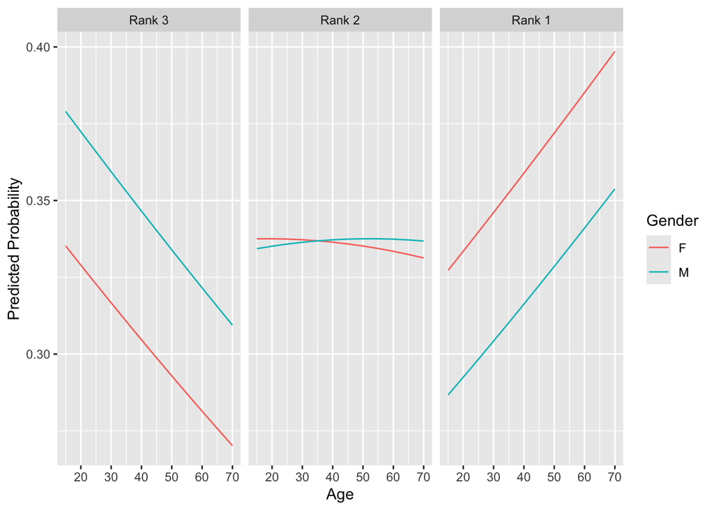

```r
ggplot(data = ggemmeans(m2, terms = c("Age", "Gender"))) +
  geom_line(aes(x = x, y = predicted, color = group)) +
  facet_wrap(~ response.level,
             labeller = as_labeller(c("3" = "Rank 3", "2" = "Rank 2", "1" = "Rank 1"))) +
  labs(x = "Age", y = "Predicted Probability", color = "Gender")
```

#### Feedback

**ImportantFeedback**

Good work! I like the custom ggplot with facet_wrap and relabeled panels.

# Part 9: Assumption Checking

### Question 9.1: Proportional odds

The proportional odds assumption says the effect of a predictor is the same at every threshold — the slope doesn’t change depending on where you split the outcome.

Use the Brant test to check this assumption. State your conclusion.

**TipHint: Which package and model object?**

`brant.test()` from the `gofcat` package requires a `polr()` model, not a `clm()` model. Refit using `MASS::polr()` first.

```r
m2_polr <- polr(Rank ~ Gender + Age, data = gb)
```

```r
brant.test(m2_polr)
```

```
Brant Test:
           chi-sq   df   pr(>chi)
Omnibus     0.367    2       0.83
GenderM     0.296    1       0.59
Age         0.075    1       0.78

H0: Proportional odds assumption holds
```

Answer: The proportional odds assumption is met.

#### Feedback

**ImportantFeedback**

Correct. The non-significant Brant test means that we fail to reject the null that slopes are equal across thresholds.

### Question 9.2: Surrogate residuals

Use the `sure` package to create a QQ plot of surrogate residuals. Does the latent normality assumption appear to hold?

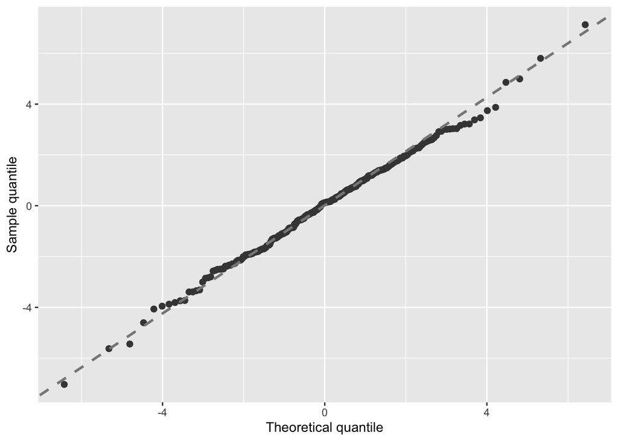

```r
autoplot.clm(m2, what ="qq")
```

Answer: The latent normality assumption seems to hold.

# Part 10: Write-Up

### Question 10.1

Write a **1-paragraph results section** for your final model. Your paragraph must include:

- The model type and link function
- Sample size
- The proportional odds test result
- At least one key coefficient reported as an odds ratio with a confidence interval
- At least one marginal effect translated into probability terms

**WarningExample write-up**

*We used a cumulative logit model (proportional odds) to predict technical rank (1st, 2nd, 3rd) from gender and age (N = [n]). A Brant test supported the proportional odds assumption (X^2 = [value], p = [value]). Gender was [not] a significant predictor of rank (OR = [value], 95% CI [[lower], [upper]], p = [value]). Each additional year of age was associated with [an increase/decrease] in the odds of achieving a better rank (OR = [value], 95% CI [[lower], [upper]]). In terms of predicted probabilities, switching from female to male [increased/decreased] the probability of achieving rank 1 by approximately [X] percentage points.*

```r
sample_size <- length(gb$Gender)     # arbitrary column -- just to get number of observations

brant.test(polr(Rank ~ Gender * Age, data = gb))
```

```
Brant Test:
               chi-sq   df   pr(>chi)
Omnibus         1.295    3       0.73
GenderM         0.585    1       0.44
Age             0.065    1       0.80
GenderM:Age     0.924    1       0.34

H0: Proportional odds assumption holds
```

```r
kable(tidy(m3, exponentiate = TRUE, conf.int = TRUE), digits = 3)
```

| term | estimate | std.error | statistic | p.value | conf.low | conf.high | coef.type |
| --- | --- | --- | --- | --- | --- | --- | --- |
| 3\|2 | 0.995 | 0.452 | -0.011 | 0.991 | NA | NA | intercept |
| 2\|1 | 4.123 | 0.460 | 3.082 | 0.002 | NA | NA | intercept |
| GenderM | 3.157 | 0.673 | 1.708 | 0.088 | 0.848 | 11.908 | location |
| Age | 1.023 | 0.012 | 1.855 | 0.064 | 0.999 | 1.049 | location |
| GenderM:Age | 0.962 | 0.019 | -2.093 | 0.036 | 0.927 | 0.997 | location |

```r
avg_comparisons(m3, variables = "Gender", type = "prob") %>%
  kable(digits = 3, caption = "Average marginal effect of Gender on each rank")
```

Average marginal effect of Gender on each rank

| term | group | contrast | estimate | std.error | statistic | p.value | s.value | conf.low | conf.high |
| --- | --- | --- | --- | --- | --- | --- | --- | --- | --- |
| Gender | 3 | M - F | 0.040 | 0.047 | 0.859 | 0.390 | 1.358 | -0.051 | 0.131 |
| Gender | 2 | M - F | 0.003 | 0.007 | 0.363 | 0.716 | 0.481 | -0.012 | 0.017 |
| Gender | 1 | M - F | -0.043 | 0.046 | -0.928 | 0.354 | 1.500 | -0.133 | 0.048 |

We used a cumulative logit model (proportional odds) to predict technical rank (1st, 2nd, 3rd) from gender and age, including the interaction between gender and age, for a sample of N = 309 participants. A Brant test supported the proportional odds assumption (X^2 = 1.295, p = 0.73). Gender was not a significant predictor of rank (OR = 3.157, 95% CI [0.848, 11.908], p = 0.088); age was also not a significant predictor of rank (OR = 1.023, 95% CI [0.999, 1.049], p = 0.064). However, the interaction of age and gender was a significant predictor of rank; each additional year of age for a male was associated with a decrease in the odds of achieving higher rank (OR = 0.962, 95% CI [0.927, 0.997], p = 0.036). In terms of predicted probabilities, switching from female to male decreased the probability of achieving rank 1 by approximately 4.3 percentage points.

#### Feedback

**ImportantFeedback**

Good write-up! I appreciate that the some of the values are pulled from the workspace (e.g. N = sample_size)

# Bonus: Probit vs. Logit

### Question B.1 (optional)

Refit Model 2 using a probit link: `clm(Rank ~ Gender + Age, data = gb, link = "probit")`.

Compare the coefficients to the logit version. Are the numbers different? Are the substantive conclusions different? In 2-3 sentences, explain why the numbers differ but the story stays the same.

#### Feedback

**ImportantFeedback**

Not attempted. The key takeaway would have been that probit coefficients are smaller but signs, significance, and the conclusions are identical.